# 6th assignment

# PCA

Now, we conduct our PCA using the “PCA” function from the “FactoMineR” package. We want the 7th variable, which is the type of sector of each company, as a supplementary qualitative. It means it will not intervene in the calculations but it will be interesting to see how it behaves when plotting some results.

```r
pca = PCA(uscomp, scale.unit = TRUE,  quali.sup = c(7), graph = FALSE)
summary(pca)
```

```
##
## Call:
## PCA(X = uscomp, scale.unit = TRUE, quali.sup = c(7), graph = FALSE)
##
##
## Eigenvalues
##                        Dim.1   Dim.2   Dim.3   Dim.4   Dim.5   Dim.6
## Variance               4.181   0.991   0.502   0.288   0.029   0.009
## % of var.             69.689  16.520   8.358   4.800   0.485   0.147
## Cumulative % of var.  69.689  86.210  94.568  99.368  99.853 100.000
##
## Individuals (the 10 first)
##                                  Dist    Dim.1    ctr   cos2    Dim.2    ctr
## Bell_Atlantic                |  3.239 |  2.681  2.175  0.685 |  1.322  2.231
## Continental_Telecom          |  0.480 | -0.140  0.006  0.085 | -0.358  0.164
## American_Electric_Power      |  1.225 |  0.688  0.143  0.315 |  0.480  0.294
## Brooklyn_Union_Gas           |  1.871 | -0.893  0.242  0.228 | -1.584  3.205
## Central_Illinois_Publ._Serv. |  1.581 | -0.586  0.104  0.137 |  1.385  2.448
## Cleveland_Electric_Illum.    |  1.579 | -0.340  0.035  0.046 | -1.508  2.905
## Columbia_Gas_System          |  0.709 | -0.494  0.074  0.484 |  0.354  0.160
## Florida_Progress             |  1.129 | -0.528  0.084  0.219 | -0.943  1.135
## Idaho_Power                  |  0.969 | -0.656  0.130  0.458 |  0.561  0.402
## Kansas_Power_Light           |  1.527 | -0.781  0.185  0.262 | -1.251  1.999
##                                cos2    Dim.3    ctr   cos2
## Bell_Atlantic                 0.167 |  0.624  0.984  0.037 |
## Continental_Telecom           0.556 | -0.132  0.044  0.075 |
## American_Electric_Power       0.154 |  0.607  0.931  0.246 |
## Brooklyn_Union_Gas            0.717 | -0.434  0.475  0.054 |
## Central_Illinois_Publ._Serv.  0.767 | -0.164  0.067  0.011 |
## Cleveland_Electric_Illum.     0.912 | -0.147  0.055  0.009 |
## Columbia_Gas_System           0.250 |  0.218  0.120  0.094 |
## Florida_Progress              0.697 | -0.240  0.145  0.045 |
## Idaho_Power                   0.335 | -0.230  0.133  0.056 |
## Kansas_Power_Light            0.671 | -0.379  0.363  0.062 |
##
## Variables
##                                 Dim.1    ctr   cos2    Dim.2    ctr   cos2
## Assets                       |  0.753 13.562  0.567 | -0.121  1.478  0.015 |
## Sales                        |  0.175  0.729  0.030 |  0.981 97.040  0.962 |
## Market Value                 |  0.981 23.003  0.962 | -0.041  0.171  0.002 |
```

[output cut: 17 more lines]

```
## Manufacturing                |  0.396 | -0.246  0.384 -0.404 |  0.020  0.003
## Medical                      |  0.680 | -0.497  0.535 -0.496 |  0.358  0.277
## Other                        |  0.597 | -0.435  0.530 -0.586 | -0.324  0.295
## Retail                       |  0.793 | -0.084  0.011 -0.139 |  0.430  0.294
## Transportation               |  0.600 | -0.542  0.814 -0.671 | -0.137  0.052
##                              v.test    Dim.3   cos2 v.test
## Communication                 0.689 |  0.246  0.026  0.495 |
## Energy                       -0.837 | -0.121  0.042 -0.732 |
## Finance                      -0.554 |  0.631  0.610  4.120 |
## HiTech                        0.428 | -0.331  0.014 -1.384 |
## Manufacturing                 0.069 | -0.048  0.015 -0.230 |
## Medical                       0.733 | -0.261  0.147 -0.752 |
## Other                        -0.897 | -0.182  0.093 -0.708 |
## Retail                        1.451 | -0.272  0.118 -1.290 |
## Transportation               -0.349 | -0.206  0.118 -0.736 |
```

Here, we decide how many dimensions we want to keep thank to the PCA.

```r
pca$var$contrib
```

```
##                   Dim.1      Dim.2      Dim.3     Dim.4        Dim.5
## Assets       13.5620450  1.4777714 82.3816697  1.713535  0.572731324
## Sales         0.7290855 97.0404116  0.6032843  1.600443  0.002999277
## Market Value 23.0029865  0.1714245  2.0136301  1.916726 71.145041094
## Profits      21.9208422  0.4527000  9.3848443  8.776482  6.532067465
## Cash Flow    22.5520097  0.2175532  5.4224227  6.121941 20.892259609
## Employees    18.2330310  0.6401393  0.1941488 79.870871  0.854901231
```

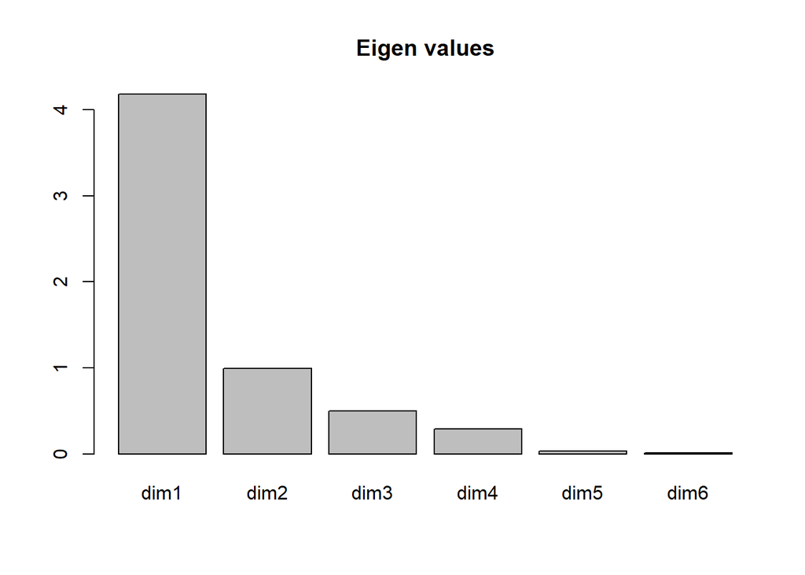

```r
barplot(pca$eig[,1], main="Eigen values", names.arg =paste0("dim",1:nrow(pca$eig)))
```

It seems to appear that keeping only the two first dimensions can help explain lots of information about the data.

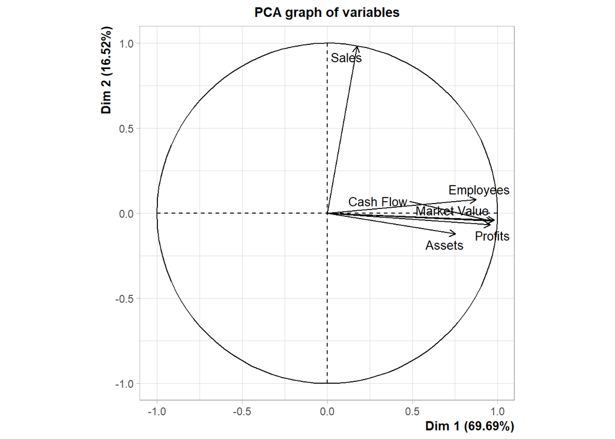

```r
plot.PCA(pca, choix ="varcor", axes=c(1,2), cex=0.9)
```